# Introduction

# Overview

Diabetes is a prevalent chronic condition affecting a significant portion of the global population. In 2021, approximately 38.4 million Americans, or 11.6% of the U.S. population, had diabetes, with 29.7 million diagnosed and 8.7 million undiagnosed. The prevalence is notably higher among seniors, with 29.2% of Americans aged 65 and older affected.(Disease Control and Prevention 2023) Globally, the number of adults diagnosed with diabetes has more than quadrupled since 1990, reaching over 800 million in 2022.(MarketWatch 2024) This alarming increase is attributed to factors such as rising obesity rates, unhealthy diets, physical inactivity, and economic challenges. The surge in diabetes cases underscores the urgent need for effective prevention and management strategies worldwide.

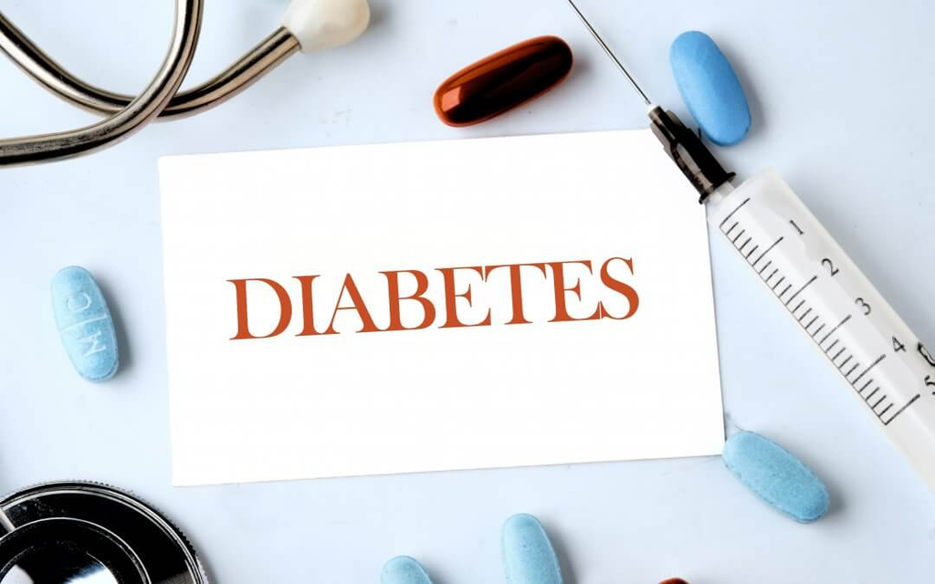

# Project Goals

Our project aims to use the Reddit **r/diabetes** subreddit text datasets of both submissions and comments from June 2023 to July 2024 to analyze and understand the discussions in the diabetes subreddit with more than 134K members. In this project, we used Exploratory Data Analysis(EDA), Natual Language Processing(NLP) and Machine Learning(ML) to answer the following research questions:

## NLP:

### Question 1

**Bussiness Goals:** What are the key topics that was discussed more frequently in the subreddit?

**Technical Proposal:** Using sparknlp to build up a text data pipeline using tokenizatoin, normalization, and lemmatization to preprocess the data, use pysparkml for TF-IDF analysis to extract key words.

### Question 2

**Bussiness Goals:** How do sentiments towards medication compare to those towards lifestyle changes?

**Technical Proposal:** Create dummy variables on different kinds of medication and different lifestyle factors(use results from question 1), aggregate them in each big category and pass them through a pre-trained sentiment model, extract results, aggregate the data for visualization using bar charts and heatmaps.

### Question 3

**Bussiness Goals:** How do sentiments vary towards different kinds of medication?

**Technical Proposal:** Instead of aggragating each category, we need to create dummy variables on specific medications, and use pre-trained sentiment model to extract results and visualize.

### Question 4

**Bussiness Goals:** How do sentiments differ between diabetes and its related symptoms?

**Technical Proposal:** Similar approach as above, needed to create dummy variables on different kinds of diabetes: Gastational, Type-1, and Type-2, and searched for the most prominent symtoms, aggregate the results to a new datasets and visualize.

**Bussiness Goals:** What is the overall trend in sentiments over time?

**Technical Proposal:** Aggragate the total sentiment results to a new data frame and plot a time-series visualization and check for patterns and changes.

### Question 5

**Bussiness Goals:** How do sentiments compare across different technologies?

**Technical Proposal:** Simmilar sentiment analysis compared with above, create dummy variables on technology equipments designed for diabetes patients, compared the sentiments.

## ML

### Question 1

**Bussiness Goals:** Predicting the Sentiment of Comments (Positive/Negative):

**Technical Proposal:** By analyzing patients’ emotional tendencies when discussing treatment plans and medications, healthcare institutions and pharmaceutical companies can understand:

1. Which treatment plans/medications receive positive feedback
2. Which aspects have issues that need improvement
3. Patient acceptance levels of new treatment approaches

### Question 2

**Bussiness Goals:** Predicting Post Engagement (High/Low Comment Count):

**Technical Proposal:** Business Significance: Helps diabetes-related health platforms understand:

1. What types of content trigger more user discussions
2. How to optimize content strategy to increase user engagement
3. Which topics are of most interest to diabetes patients

## References

Disease Control, Centers for, and Prevention. 2023. “National Diabetes Statistics Report.” https://www.cdc.gov/diabetes/php/data-research/index.html.

MarketWatch. 2024. “Surging Diabetes Rate Underscores Vast Opportunity in Weight-Loss Drugs.” https://www.marketwatch.com/story/surging-diabetes-rate-underscores-vast-opportunity-in-weight-loss-drugs-c7d37bfd.